# Analýza priemerných miezd v štátoch Európskej únie

Jedným z najdôležitejších ukazateľov (aj keď nie jediným) kvality života v rôznych štátoch je nesporne priemerná mesačná mzda. V tejto práci sa zamerám na jej analýzu vo vybraných štátoch Európskej únie v roku 2015.

Hlavnými cieľmi práce sú odpovedať na nasledujúce otázky:

- Aké hodnoty má sledovaná veličina? Aká je priemerná mzda naprieč EÚ? Ktoré štáty najviac vyčnievajú?
- Aké iné veličiny ovplyvňujú mzdu? Ktoré z nich majú najväčší dopad?
- Ako je možné z daných veličín aproximovať reálnu hodnotu priemernej mzdy? Je daný vzťah spoľahlivý?

### Načítanie knižníc

```r
library(eurostat)
library(corrplot)
library(vtable)
library(car)
#install.packages("psych")
library(psych)
#install.packages("plotly")
library(plotly)
library(lmtest)
```

## Úloha 1

- Krátce prezentujte rozdělení průměrných mezd a jeho charakteristiky číselně i graficky.
- Diskutujte, které údaje o zemích by mohly mít na průměrné mzdy vliv.

### Priemerná mzda

Hodnoty priemernej mzdy získam z Eurostatu, konkrétne z datasetu *nama_10_fte*. Ten obsahuje dáta z 26 krajín EÚ, v skúmanom roku 2015 však chýba *Spojené kráľovstvo*, ktoré vtedy ešte bolo súčasťou EÚ, a *Holandsko*, ktoré je v metadátach uvedené ako chýbajúce, každopádne bez udania dôvodu.

Dataset takisto obsahuje priemernú mzdu **EU27_2020**, ktorá je pre 27 krajín súčasneho zloženia EÚ (vrátane Holandska), táto hodnota však práve kvôli Spojenému kráľovstvu nie je priemernou mzdou EÚ v tom čase, ničmenej vo vizualizáciách ju s ňou stotožním. V geografickej polohe môžeme nájsť aj **EA20**, ktorá je vypočítaná ako priemerná mzda pre 20 krajín súčasnej eurozóny (množine členov EÚ, ktorí používajú spoločnú menu - euro). Ani tento ukazateľ sa nezaobíde bez nepresností, keďže v skúmanom roku 2015, mala eurozóna 19 členov (*Chorvátsko* prijalo euro v roku 2023). Takisto ako vyššie, zmenu vo vizualizáciách zanedbávam.

Menou, v ktorej budem skúmať mzdy, bude euro. A keďže nie sme zvyknutý na ročnú mzdu, pre lepšie predstavenie ju prevediem na mesačnú.

```r
# dataset s priemernymi mzdami
salary = get_eurostat('nama_10_fte')

# skumane obdobie a mena
salary = salary[salary$TIME_PERIOD == '2015-01-01',]
salary = salary[salary$unit == 'EUR',]

# sledovane regiony
countries_2015 = unique(salary$geo)

# nepotrebne udaje zmazem
salary$freq = NULL
salary$unit = NULL
salary$TIME_PERIOD = NULL
names(salary) = c('geo', 'salary')

# prevod rocnej priemernej mzdy na mesacnu
salary$salary = as.integer(salary$salary / 12)

# rozdelenie na krajiny a skupiny krajin
salary_eu = salary[-grep('^.{2}$' , salary$geo),]
salary = salary[grep('^.{2}$' , salary$geo),]

salary$geo = as.factor(salary$geo)
salary
```

```
## # A tibble: 26 × 2
##    geo   salary
##    <fct>  <int>
##  1 AT      3489
##  2 BE      3677
##  3 BG       531
##  4 CY      1724
##  5 CZ      1033
##  6 DE      3330
##  7 DK      4742
##  8 EE      1136
##  9 EL      1416
## 10 ES      2264
## # ℹ 16 more rows
```

#### Charakteristika

Pozrieme sa bližšie na významné štatistické miery.

```r
summ <- c('notNA(x)', 'mean(x)', 'sd(x)', 'min(x)', 'pctile(x)[25]',
          'median(x)', 'pctile(x)[75]', 'max(x)', 'IQR(x)')
sumtable(data.frame(salary$salary), out="return", summ=summ)
```

```
##        Variable NotNA Mean   Sd Min Pctile[25] Median Pctile[75]  Max  IQR
## 1 salary.salary    26 2159 1347 531       1031   1782       3366 5116 2335
```

Vidíme, že skutočne máme 26 štátov, s najmenšou priemernou mzdou 531€ a najvyššou 5116€. Čo je takmer desaťnásobok, môžeme teda očakávať že mzdy budú veľmi rozptýlené, čo dosvedčuje aj vysoká smerodatná odchýlka. Ďalej je možné vidieť, že aj priemer týchto priemerov je vyšší ako medián, čo znamená, že máme málo veľmi bohatých štátov.

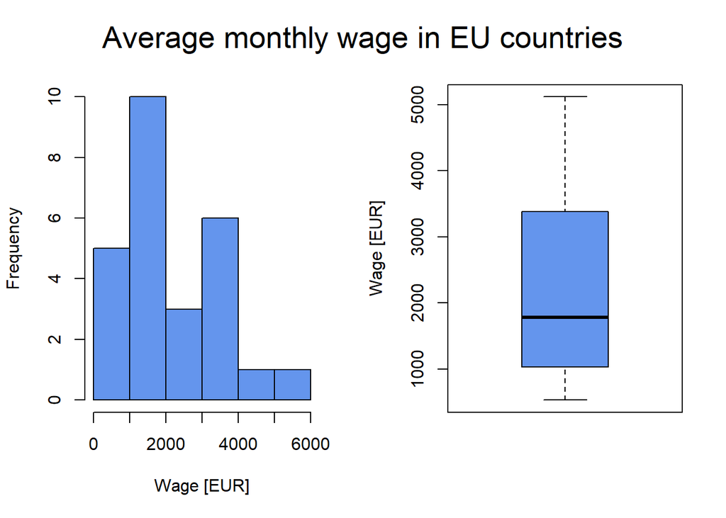

```r
par(mfrow = c(1, 2))
hist(salary$salary, main = '', xlab = 'Wage [EUR]', ylab = 'Frequency', col = 'cornflowerblue')
boxplot(salary$salary, ylab = 'Wage [EUR]', col = 'cornflowerblue')
mtext('Average monthly wage in EU countries', outer = TRUE, cex = 1.75, line = -2.5)
```

Na histograme vidíme, akoby bola Únia rozdelená na chudobnejšiu (1000 - 2000€) a bohatšiu (3000 - 4000€) časť. Samozrejme je vidieť aj 3 štáty ktoré sú medzi týmito skupinami. Máme aj veľmi chudobné štáty (na európske pomery), ktoré majú priemernú mzdu pod 1000€, ale aj veľmi bohaté štáty nad 4000€.

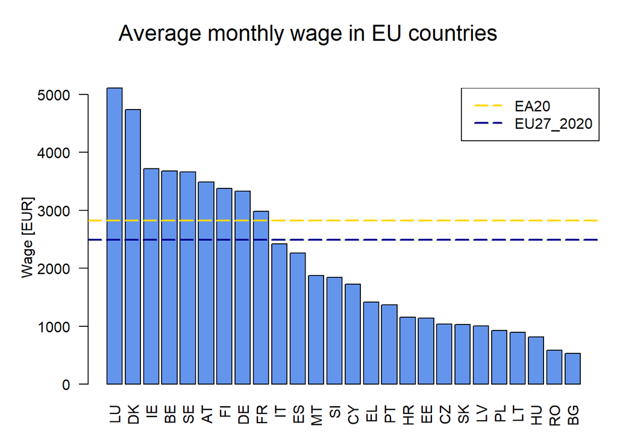

```r
par(mar=c(3,5,5,1))
ordered_data = salary[order(salary$salary, decreasing = TRUE),]

barplot(ordered_data$salary, names.arg = ordered_data$geo, ylab = 'Wage [EUR]',
        col = 'cornflowerblue', las= 2)
abline(a = salary_eu[salary_eu$geo == 'EA20',]$salary, b = 0, lwd = 2, col = 'gold', lty = 5)
abline(a = salary_eu[salary_eu$geo == 'EU27_2020',]$salary, b = 0, lwd = 2, col = 'darkblue', lty = 5)
legend('topright', legend=c('EA20', 'EU27_2020'), col = c('gold', 'darkblue'), lwd = 2, lty = 5)
mtext('Average monthly wage in EU countries', outer = TRUE, cex = 1.5, line = -2.5)
```

Rebríček najvyšších miezd neprekvapivo otvára *Luxembursko* nasledované *Dánskom* a *Írskom*. Najnižšie mzdy sú v *Bulharsku* a *Rumunsku*. Ďalej je možné vidieť, že priemerná mzda v eurozóne je vyššia ako v celej EÚ súhrnne. Najväčšie krajiny EÚ ako *Nemecko*, *Francúzsko* a *Taliansko* ovplyvňujú celkovú priemernú mzdu výraznejšie ako ostatné štáty a teda sú aj blízko priemeru za EÚ.

### Faktory ovplyvňujúce priemernú mzdu

Existuje množstvo údajov, ktoré majú dané štáty odlišné. Chceme sa však zamerať na také ukazatele, ktoré by mohli mať vplyv na priemernú mzdu v štáte.

**HDP na obyvateľa** môže hrať snáď najdôležitejšiu rolu. Veľmi dôležitý ukazateľ, ktorý sa často globálne používa aj sám osebe ako numerickým vyjadrením kvality krajiny. Asi je pomerne intuitívny nápad, že kde je viac peňazí, tam sa aj viac ujde jednotlivcovi.

Z vyššieho grafu je vidno napríklad, že z prvých troch krajín používajú **euro** dve, z posledných ani jedna. Navyše priemer eurozóny je vyšší ako celej EÚ, teda je logické uvažovať aj tento vplyv. Na prijatie do eurozóny je potrebné splniť prísne ekonomické podmienky, čo teda môže znamenať, že krajine sa ekonomicky darí, tým pádom môže byť predpoklad na vyššiu mzdu oprávnený.

Veľmi často sa stretávame aj s tvrdeniami, že titul z **vysokej školy** zabezpečí osobe nadpriemerný príjem. Preto má zmysel uvažovať podiel absolventov týchto škôl v populácii krajiny. Títo absolventi sú schopní vykonávať práce s vysokými požiadavkami na znalosti, ktoré sú aspoň do istej miery odmenené.

Pozorné očko si v grafe vyššie všimne, že všetky krajiny nad európskym priemerom sa **pripojili k EÚ** ešte v minulom storočí (dokonca tisícročí). Na vstup do EÚ je potrebné tiež splniť radu požiadaviek. Členstvo v EÚ poskytuje priaznivé prostredie pre obchod a celkovo legislatívny aparát podporujúci rast miezd. Netreba zabudnúť ani na eurofondy, ktoré krajina čerpá aj na podporu zamestnania.

## Úloha 2:

- Pro zkoumané země si vhodně zvolte čtyři údaje dostupné z databází Eurostatu či jiných externích zdrojů. Může se jednat např. o demografické, geografické nebo ekonomické ukazatele. Alespoň jedna proměnná nechť je numerická a alespoň jedna kategoriální (např. zda má země přístup k moři, zda se v zemi platí Eurem, jestli se jedná o monarchii nebo republiku,…).
- Tyto údaje budou sloužit jako regresory, proto je zvolte tak, aby modelovanou veličinu alespoň v minimální míře determinovaly. Vztah k mzdám ověřte.
- Prezentujte důležité vlastnosti zvolených ukazatelů číselně i graficky.
- Pomocí vhodných testů prozkoumejte závislosti mezi regresory.

### HDP na obyvateľa

Dáta získam z Eurostatu, konkrétne z *tipsna40*. Dataset obsahuje údaje o hodnote HDP na obyvateľa vo vybraných európskych krajinách. Ja sa zameriam na rok 2015 a krajiny v ktorých mám priemernú mzdu.

```r
gdp = get_eurostat('tipsna40')

# zúženie dát na 2015 a krajiny z datasetu so mzdami
gdp = gdp[gdp$TIME_PERIOD == '2015-01-01',]
gdp = gdp[gdp$geo %in% countries_2015,]
gdp$freq = NULL
gdp$unit = NULL
gdp$na_item = NULL
gdp$TIME_PERIOD = NULL

names(gdp) = c('geo', 'gdp')

# uloženie dát na vizualizáciu a analýzu zvlášť
gdp_eu = gdp[-grep('^.{2}$' , gdp$geo),]
gdp = gdp[grep('^.{2}$' , gdp$geo),]

gdp$geo = as.factor(gdp$geo)
gdp
```

```
## # A tibble: 26 × 2
##    geo     gdp
##    <fct> <dbl>
##  1 AT    39640
##  2 BE    36860
##  3 BG     6560
##  4 CY    20810
##  5 CZ    16230
##  6 DE    37770
##  7 DK    47900
##  8 EE    16000
##  9 EL    16210
## 10 ES    23440
## # ℹ 16 more rows
```

#### Charakteristika

```r
summ <- c('notNA(x)', 'mean(x)', 'sd(x)', 'min(x)', 'pctile(x)[25]',
          'median(x)', 'pctile(x)[75]', 'max(x)', 'IQR(x)')
sumtable(data.frame(gdp$gdp), out="return", summ=summ)
```

```
##   Variable NotNA  Mean    Sd  Min Pctile[25] Median Pctile[75]   Max   IQR
## 1  gdp.gdp    26 26936 19619 6560      13350  19735      37543 95090 24193
```

Je vidno obrovský rozdiel medzi priemerom a mediánom, preto očakávam, že tu bude zopár skutočne odľahlých hodnôt.

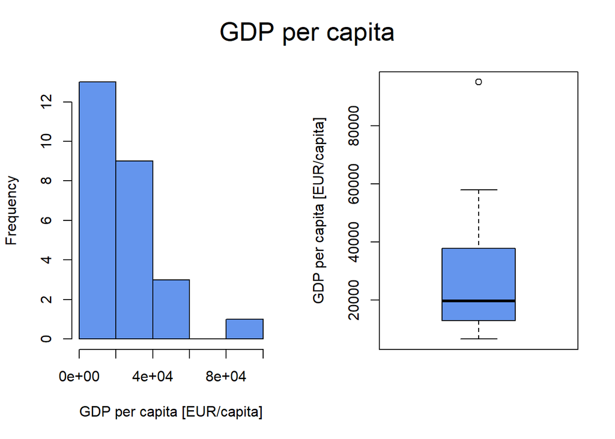

```r
par(mfrow = c(1, 2))
hist(gdp$gdp, main = '', xlab = 'GDP per capita [EUR/capita]', ylab = 'Frequency', col = 'cornflowerblue')
boxplot(gdp$gdp, ylab = 'GDP per capita [EUR/capita]', col = 'cornflowerblue')
mtext('GDP per capita', outer = TRUE, cex = 1.75, line = -2.5)
```

Na grafe je vidno, že veľká väčšina krajín má HDP na obyvateľa do 40 tisíc eur. Nad touto hranicou sa nachádzajú už len štyri krajiny.

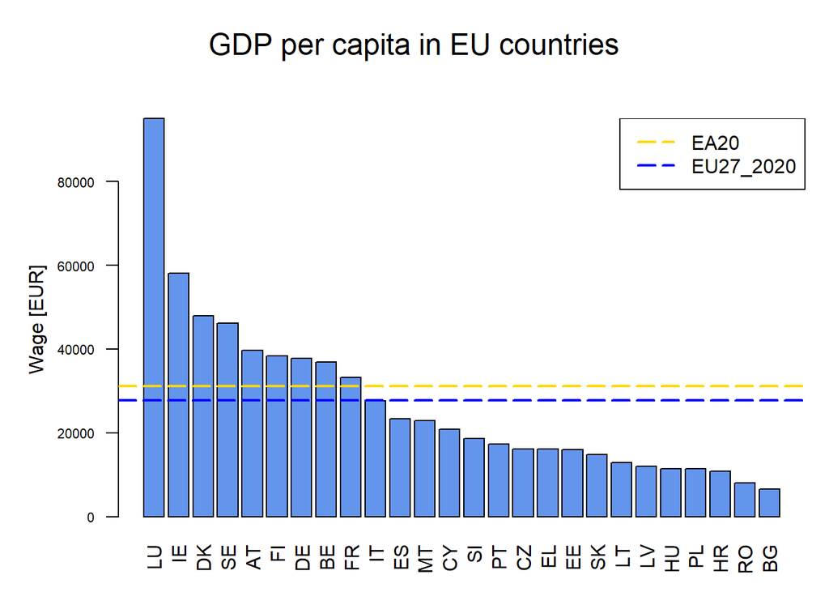

```r
par(mar=c(3,5,5,1))
ordered_data = gdp[order(gdp$gdp, decreasing = TRUE),]

barplot(ordered_data$gdp, names.arg = ordered_data$geo, ylab = 'Wage [EUR]',
        col = 'cornflowerblue', las= 2, cex.axis = 0.7)
abline(a = gdp_eu[gdp_eu$geo == 'EA20',]$gdp, b = 0, lwd = 2, col = 'gold', lty = 5)
abline(a = gdp_eu[gdp_eu$geo == 'EU27_2020',]$gdp, b = 0, lwd = 2, col = 'blue', lty = 5)
legend('topright', legend=c('EA20', 'EU27_2020'), col = c('gold', 'blue'), lwd = 2, lty = 5)
mtext('GDP per capita in EU countries', outer = TRUE, cex = 1.5, line = -2.5)
```

Máme možnosť vidieť takmer identický graf ako graf priemerných mesačných miezd. Výrazným rozdielom je ešte vytŕčajúce *Luxembursko*, ktoré to dosahuje hlavne kvôli svojej malej populácii.

#### Vzťah s priemernou mzdou

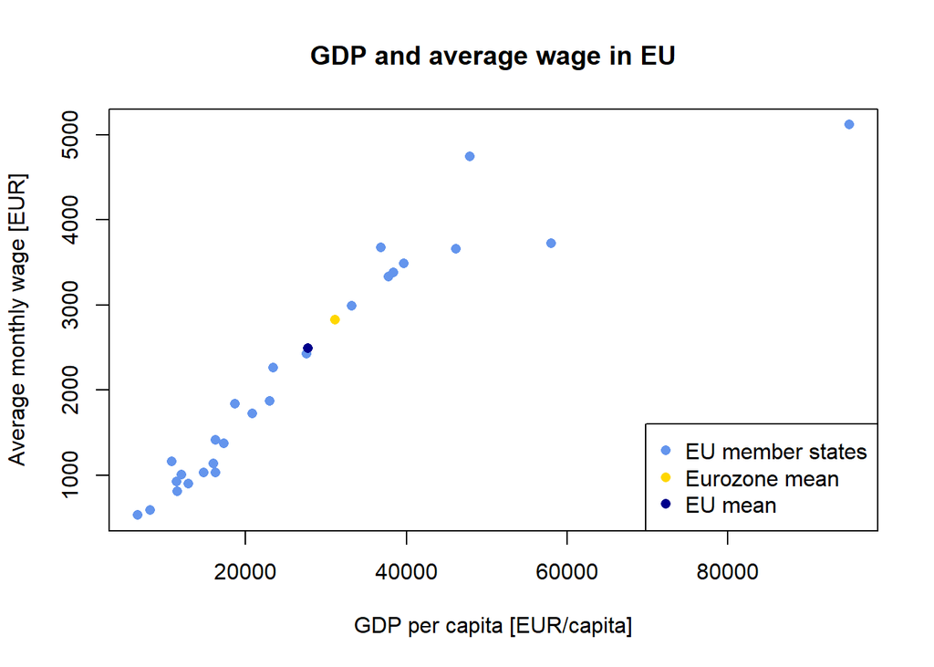

```r
data = merge(gdp, salary)
data_eu = merge(gdp_eu, salary_eu)
plot(data$gdp, data$salary, col = 'cornflowerblue', pch = 16, main='GDP and average wage in EU',
     xlab = 'GDP per capita [EUR/capita]', ylab = 'Average monthly wage [EUR]')
points(data_eu$gdp, data_eu$salary, col=c('gold', 'darkblue'), pch=16)
legend('bottomright', legend = c('EU member states', 'Eurozone mean', 'EU mean'),
       col = c('cornflowerblue', 'gold', 'darkblue'), pch = 16)
```

Až na zopár bodov, je vidno, že medzi veličinami je takmer dokonalý lineárny vzťah. Pozrime sa preto na Pearsonov korelačný koeficient a otestujme.

$H_0 : \rho = 0$

$H_A : \rho \ne 0$

```r
cor.test(data$gdp, data$salary, method = 'pearson')
```

```
##
##  Pearson's product-moment correlation
##
## data:  data$gdp and data$salary
## t = 11.743, df = 24, p-value = 1.953e-11
## alternative hypothesis: true correlation is not equal to 0
## 95 percent confidence interval:
##  0.8335444 0.9652092
## sample estimates:
##       cor
## 0.9229113
```

Na hladine $\alpha = 5 \%$ zamietam $H_0$ v prospech hypotézy, že veličiny sú korelované.

### Členstvo v eurozóne

Dáta získam z verejne dostupných informácií a uložím do jednoduchého dataframe-u.

```r
eurozone_member = data.frame(
  geo = countries_2015[grep('^.{2}$', countries_2015)],
  euro = c(1, 1, 0, 1, 0, 1, 0, 1, 1, 1, 1, 1, 0, 0, 1, 1, 1, 1, 1, 1, 0, 1, 0, 0, 1, 1)
)
eurozone_member$geo = as.factor(eurozone_member$geo)
eurozone_member$euro = as.factor(eurozone_member$euro)
data = merge(data, eurozone_member)
```

### Charakteristika a vplyv na platy

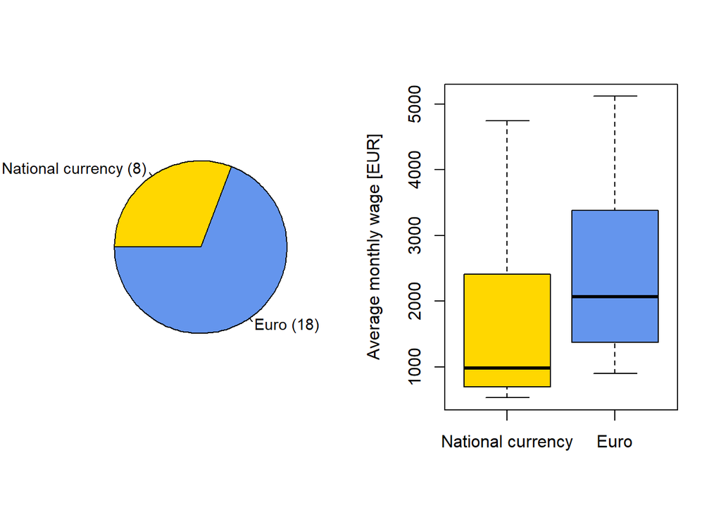

```r
par(mfrow = c(1, 2))

# factor je cislovany od 1
with_euro = sum(as.integer(data$euro) - 1)

pie(c(with_euro, length(data$euro) - with_euro),
    labels = c(paste0('Euro (', with_euro, ')'),
               paste0('National currency (', length(data$euro) - with_euro, ')')),
    init.angle = 180,
    col = c('cornflowerblue', 'gold'),
    cex = 0.9)

boxplot(data$salary ~ data$euro,
        col = c('gold', 'cornflowerblue'),
        ylab = 'Average monthly wage [EUR]', xlab = '',
        names = c('National currency', 'Euro'))
```

Ako môžeme vidieť, zo sledovaných štátov platia viac ako dve tretiny eurom. Takisto je vidno, že priemerný plat v štátoch platiacich eurom je okolo tisícky vyšší ako kde platia vlastnou menou. Napriek malému počtu krajín používajúcich národnú menu, je rozptyl hodnôt takmer rovnaký ako s dvakrát početnejšou skupinou používajúcich euro.

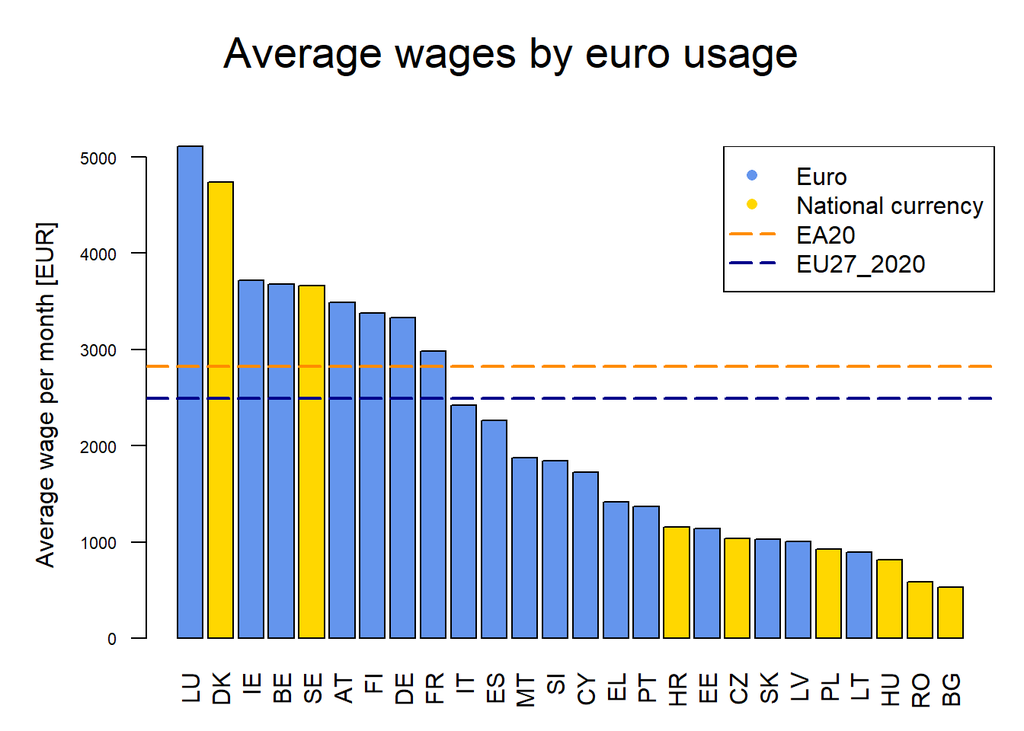

```r
par(mar=c(3,5,5,1))

salary_eu$euro = NA

data_with_cat = data[c('geo', 'salary', 'euro')]
data_with_cat = data_with_cat[order(data_with_cat$salary, decreasing = TRUE),]
data_with_cat$cat = ifelse(data_with_cat$euro == 1, 'cornflowerblue', 'gold')

barplot(data_with_cat$salary, names.arg = data_with_cat$geo, ylab = 'Average wage per month [EUR]',
        col = data_with_cat$cat, las= 2, cex.axis = 0.7)
abline(a = salary_eu[salary_eu$geo == 'EA20',]$salary, b = 0, lwd = 2, col = 'darkorange', lty = 5)
abline(a = salary_eu[salary_eu$geo == 'EU27_2020',]$salary, b = 0, lwd = 2, col = 'darkblue', lty = 5)
mtext('Average wages by euro usage', outer = TRUE, cex = 1.75, line = -2.5)
legend('topright', legend = c('Euro', 'National currency', 'EA20', 'EU27_2020'),
       col = c('cornflowerblue', 'gold', 'darkorange', 'darkblue'), pch = c(16, 16, -1, -1), lty = c(0, 0, 5, 5), lwd = c(0, 0, 2, 2))
```

Z grafu je očividné, kde sa berie vysoká variancia pre štáty platiace národnou menou. Môžeme v tejto skupine nájsť dve vysoko nadpriemerné štáty, čo sa platov týka, *Dánsko*, ktoré má z povinnosti prijať euro výnimku a *Švédsko*. Ostatné štáty nepoužívajúce euro majú platy nižšie ako polovica z priemeru eurozóny. Tam je však možné nájsť aj nenulový počet krajín s eurom.

Poďme teda otestovať vplyv eura na strednú hodnotu mesačných platov.

$H_0 :$ Stredná hodnota mesačných platov nezávisí na používaní eura.

$H_A :$ neplatí $H_0$.

```r
anova(aov(data$salary ~ data$euro))
```

```
## Analysis of Variance Table
##
## Response: data$salary
##           Df   Sum Sq Mean Sq F value Pr(>F)
## data$euro  1  2638242 2638242  1.4828 0.2352
## Residuals 24 42700160 1779173
```

Nezamietam hypotézu $H_0$ na hladine významnosti $5 \%$.

### Vysoké školy

Dáta sú z Eurostatu a ide o dataset *edat_lfse_03*. Dataset obsahuje mnoho údajov o absolventoch škôl v európskych štátoch. Ja sa budem sústrediť na nami skúmané štáty v roku 2015. Ďalej ma budú zaujímať všetky pohlavia a najširšia veková skupina ktorú dataset ponúka - 15 až 64 rokov. V tejto vekovej skupine sú uvedené percentá, koľko ĺudí má absolvovaný daný typ školy. Uvažuje sa len najvyššie dosiahnuté vzdelanie.

Ďalej ma budú zaujímať len absolventi týchto úrovní vzdelania podľa štandardu *ISCED 2011*:

- úroveň 5 - krátkodobé úspešne ukončené vysokoškolské vzdelanie,
- úroveň 6 - bakalárske vzdelanie,
- úroveň 7 - magisterské vzdelanie,
- úroveň 8 - doktorandské vzdelanie,

spolu združené v kategórii *ED5-8*.

```r
edu = get_eurostat('edat_lfse_03')
edu = edu[edu$TIME_PERIOD == '2015-01-01',]
edu = edu[edu$isced11 == 'ED5-8',]
edu = edu[edu$geo %in% countries_2015,]
edu = edu[edu$sex == 'T',]
edu = edu[edu$age == 'Y15-64',]

edu$freq = NULL
edu$sex = NULL
edu$age = NULL
edu$unit = NULL
edu$isced11 = NULL
edu$TIME_PERIOD = NULL
names(edu) = c('geo', 'edu')

edu_eu = edu[-grep('^.{2}$' , edu$geo),]
edu = edu[grep('^.{2}$' , edu$geo),]

edu$geo = as.factor(edu$geo)

edu
```

```
## # A tibble: 26 × 2
##    geo     edu
##    <fct> <dbl>
##  1 AT     28.1
##  2 BE     32.7
##  3 BG     24.1
##  4 CY     36.4
##  5 CZ     19.8
##  6 DE     23.8
##  7 DK     30.2
##  8 EE     32
##  9 EL     25.4
## 10 ES     32.1
## # ℹ 16 more rows
```

#### Charakteristika

```r
summ <- c('notNA(x)', 'mean(x)', 'sd(x)', 'min(x)', 'pctile(x)[25]',
          'median(x)', 'pctile(x)[75]', 'max(x)', 'IQR(x)')
sumtable(data.frame(edu$edu), out="return", summ=summ)
```

```
##   Variable NotNA Mean  Sd Min Pctile[25] Median Pctile[75] Max IQR
## 1  edu.edu    26   27 6.8  15         21     27         33  39  12
```

Podiel absolventov vysokých škôl je zatiaľ najviac vyrovnaným ukazovateľom v EÚ. Priemer medzi krajinami by sme našli presne kde medián - na hodnote 27%. Polovica krajín má vysokoškolskú vzdelanosť na úrovni medzi 21 a 33 percent.

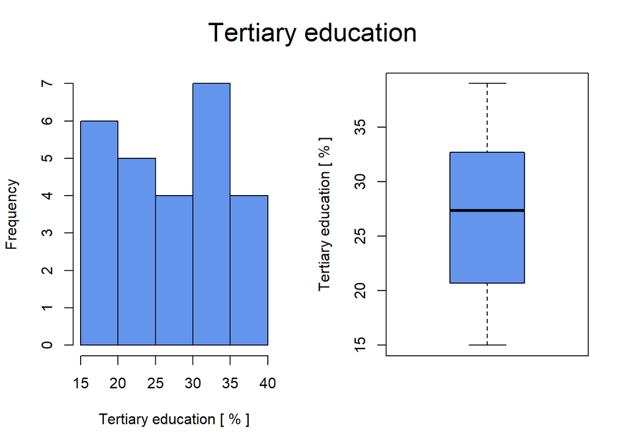

```r
par(mfrow = c(1, 2))
hist(edu$edu, main = '', xlab = 'Tertiary education [ % ]', ylab = 'Frequency', col = 'cornflowerblue')
boxplot(edu$edu, ylab = 'Tertiary education [ % ]', col = 'cornflowerblue')
mtext('Tertiary education', outer = TRUE, cex = 1.75, line = -2.5)
```

Tak ako vyššie čísla naznačovali, skutočne dáta vyzerajú takmer ako z rovnomerného rozdelenia.

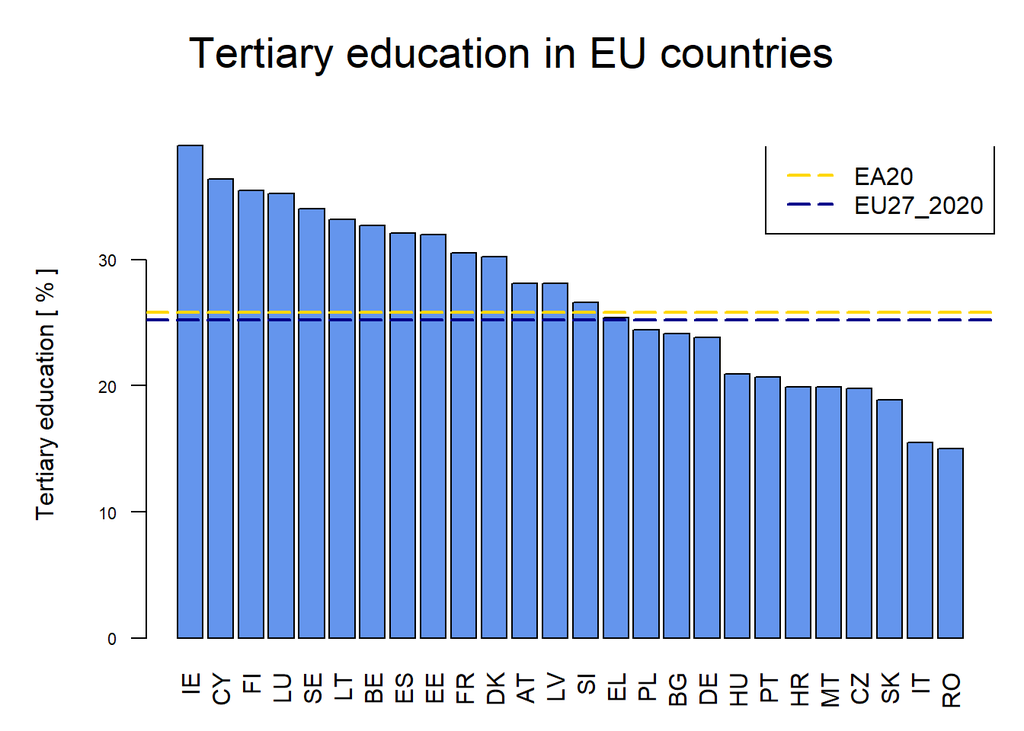

```r
par(mar=c(3,5,5,1))
ordered_data = edu[order(edu$edu, decreasing = TRUE),]

barplot(ordered_data$edu, names.arg = ordered_data$geo, ylab = 'Tertiary education [ % ]',
        col = 'cornflowerblue', las= 2, cex.axis = 0.7)
abline(a = edu_eu[edu_eu$geo == 'EA20',]$edu, b = 0, lwd = 2, col = 'gold', lty = 5)
abline(a = edu_eu[edu_eu$geo == 'EU27_2020',]$edu, b = 0, lwd = 2, col = 'darkblue', lty = 5)
legend('topright', legend = c('EA20', 'EU27_2020'),
       col = c('gold', 'darkblue'), lty = 5, lwd = 2)
mtext('Tertiary education in EU countries', outer = TRUE, cex = 1.75, line = -2.5)
```

Najvyššie úrovne vysokoškolského vzdelania sú v *Írsku*, na *Cypre* a vo *Fínsku*. Írske a fínske školy sú celosvetovo známe pre svoju kvalitu, preto nie je prekvapením, že miestni vidia možno väčší zmysel v štúdiu ako priemerný občan EÚ. Cyprus je prekvapivým štátom, vysoký podiel môže byť zapríčinený blízkym ľudnatým Tureckom a všeobecne je najbližším EÚ štátom aj pre Blízky východ a časť Afriky. Týchto ľudí z okolia možno láka geografická blízkosť a vidina uznávaného titulu z členského štátu EÚ. Táto krajina je tiež známa nízkou daňovou záťažou a preto má veľa firiem (formálne) sídlo pre EÚ práve tu. No a je všeobecne známe, že korporáty si potrpia na vzdelanie.

Najnižšie môžeme nájsť v *Rumunsku*, *Taliansku* a na *Slovensku*. Rumunsko a Slovensko sú určite krajiny, ktoré trpia “odlivom mozgov”. Ťažko nájsť dôvod prečo sa však nedarí Taliansku. Môže byť, že v krajine sa nie je veľký problém zamestnať bez vysokej školy a tak nie je veľmi populárnou voľbou. Je tiež známe, že napriek veľmi rozvinutému severu krajiny, na juhu možnosti zďaleka nie sú rovnaké, tento rozdiel v regiónoch sa možno práve v tejto štatistike odzrkadľuje.

#### Vzťah s priemernou mzdou

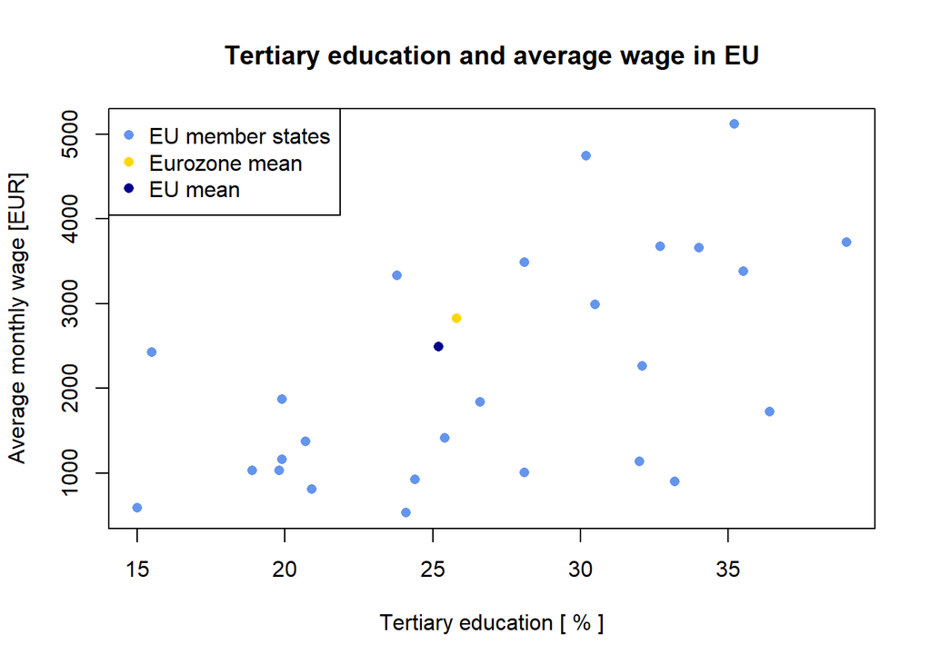

```r
data = merge(data, edu)
data_eu = merge(data_eu, edu_eu)
plot(data$edu, data$salary, col = 'cornflowerblue', pch = 16, main='Tertiary education and average wage in EU',
     xlab = 'Tertiary education [ % ]', ylab = 'Average monthly wage [EUR]')
points(data_eu$edu, data_eu$salary, col=c('gold', 'darkblue'), pch=16)
legend('topleft', legend = c('EU member states', 'Eurozone mean', 'EU mean'),
       col = c('cornflowerblue', 'gold', 'darkblue'), pch = 16)
```

Preložiť tieto body nejakou priamkou asi veľmi zmysel nedáva. Minimálne však je vidno, že väčšinou s úrovňou vysokoškolského vzdelania rastie aj priemerný plat.

Poďme si koreláciu otestovať testom nulovosti *Pearsonovho* korelačného koeficientu.

$H_0 : \rho = 0$

$H_A : \rho \ne 0$

```r
cor.test(data$edu, data$salary, method = 'pearson')
```

```
##
##  Pearson's product-moment correlation
##
## data:  data$edu and data$salary
## t = 3.292, df = 24, p-value = 0.003071
## alternative hypothesis: true correlation is not equal to 0
## 95 percent confidence interval:
##  0.2173567 0.7771927
## sample estimates:
##       cor
## 0.5577497
```

Na hladine $\alpha = 5 \%$ zamietam $H_0$ v prospech hypotézy, že veličiny sú korelované.

### Dĺžka členstva v EÚ

Údaje o dĺžke členstva som získal z verejne dostupných zdrojov.

```r
joined = data.frame(
  geo = countries_2015[grep('^.{2}$' , countries_2015)],
  in_eu = 2015 - c(1995, 1958, 2007, 2004, 2004, 1958, 1973, 2004, 1981, 1986,
                    1995, 1958, 2013, 2004, 1973, 1958, 2004, 1958, 2004, 2004,
                    2004, 1986, 2007, 1995, 2004, 2004)
)
joined$geo = as.factor(joined$geo)
data = merge(data, joined)
```

#### Charakteristika

```r
summ <- c('notNA(x)', 'mean(x)', 'sd(x)', 'min(x)', 'pctile(x)[25]',
          'median(x)', 'pctile(x)[75]', 'max(x)', 'IQR(x)')
sumtable(data.frame(data$in_eu), out="return", summ=summ)
```

```
##     Variable NotNA Mean Sd Min Pctile[25] Median Pctile[75] Max IQR
## 1 data.in_eu    26   25 19   2         11     16         40  57  29
```

Najstarší členovia (zakladajúci) sú v Únii už 57 rokov (od 1958). Najmladšie *Chorvátsko* sa pripojilo pred dvomi rokmi. Časovým obdobím, ktoré rozdeľuje Úniu na (takmer) rovnako veľké dve časti starých a nových členov je 16 rokov.

#### Vzťah s priemernou mzdou

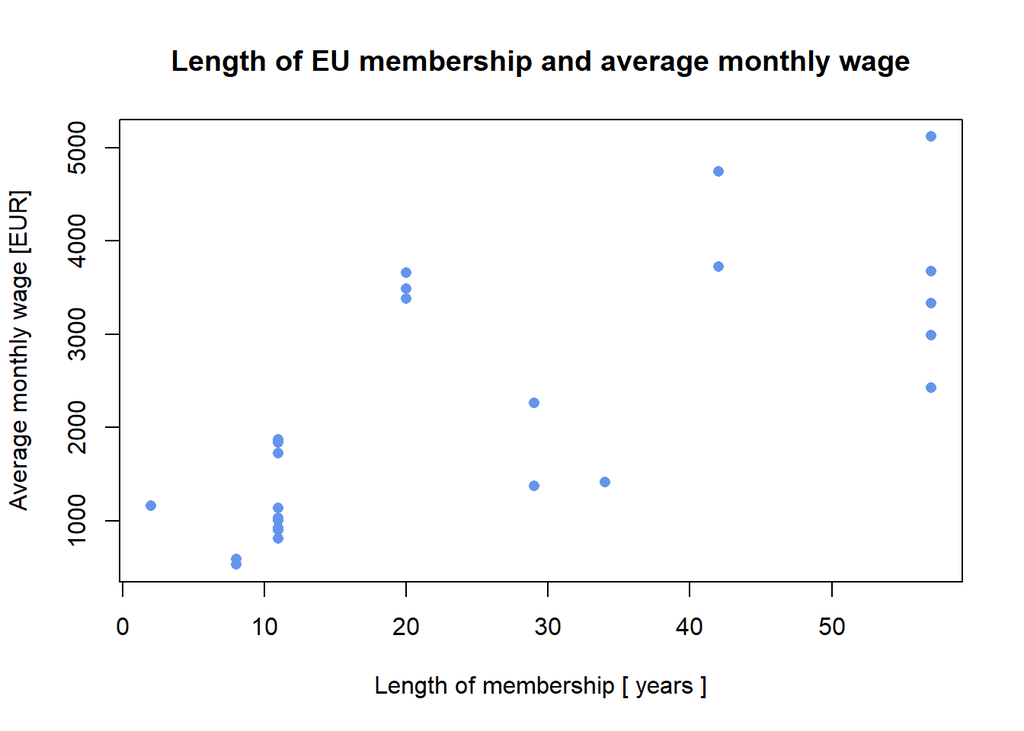

```r
plot(data$in_eu, data$salary, col = 'cornflowerblue', pch = 16, main='Length of EU membership and average monthly wage',
     xlab = 'Length of membership [ years ]', ylab = 'Average monthly wage [EUR]')
```

Tu by sa vzťah hľadal jednoduchšie ako pri vzdelaní. Pre rôzne tvrdenia o zmene v čase nemám momentálne údaje a sústredím sa na jeden rok. Je však asi celkom pochopiteľné, že za bežných okolností, čím dlhší je čas stravéný v EÚ, tým viac môžu meniť štáty meniť ekonomiku na vzor vyspelejšieho jadra. Takisto sa zvyšuje aj tlak na zvyšovanie miezd, keďže práca v zahraničí už nie je taký problém.

Tvrdenia podporím testom nulovosti *Pearsonovho* korelačného koeficientu.

$H_0 : \rho = 0$

$H_A : \rho \ne 0$

```r
cor.test(data$in_eu, data$salary, method = 'pearson')
```

```
##
##  Pearson's product-moment correlation
##
## data:  data$in_eu and data$salary
## t = 5.2116, df = 24, p-value = 2.434e-05
## alternative hypothesis: true correlation is not equal to 0
## 95 percent confidence interval:
##  0.4754639 0.8703371
## sample estimates:
##       cor
## 0.7286238
```

Na hladine $\alpha = 5 \%$ zamietam $H_0$ v prospech hypotézy, že veličiny sú korelované.

### Korelačná analýza regresorov

Overme ako jednotlivé regresory spolu korelujú testom nulovosti *Pearsonových* korelačných koeficientov. Máme teda hypotézy:

$H_{0; i, j} : \rho_{i, j} = 0$

$H_{A; i, j} : \rho_{i, j} \ne 0$

kde $i,j \in \{\text{HDP}, \text{vzdelanie}, \text{euro}, \text{dĺžka členstva} \}$.

Na testovanie využijem funkciu *corr_test* z knižnice `psych`. Tá spočíta odhady $\rho_{i,j}$ a $p$-hodnoty všetkých dvojíc regresorov. Keďže regresor *euro* je kategorický, pretypujem ho v súlade s *one-hot encoding* na numerický.

```r
data_for_corr_test = data[c('gdp', 'edu', 'euro', 'in_eu')]
data_for_corr_test$euro = as.integer(data_for_corr_test$euro) - 1

res = corr.test(data_for_corr_test, method = "pearson", adjust = "none")

res$r
```

```
##             gdp       edu      euro     in_eu
## gdp   1.0000000 0.5566751 0.2461087 0.6672482
## edu   0.5566751 1.0000000 0.3441285 0.2463564
## euro  0.2461087 0.3441285 1.0000000 0.3893163
## in_eu 0.6672482 0.2463564 0.3893163 1.0000000
```

```r
res$p
```

```
##                gdp         edu       euro        in_eu
## gdp   0.0000000000 0.003140757 0.22553391 0.0001965959
## edu   0.0031407566 0.000000000 0.08516985 0.2250521959
## euro  0.2255339092 0.085169847 0.00000000 0.0493160904
## in_eu 0.0001965959 0.225052196 0.04931609 0.0000000000
```

Z výslednej matice $p$-hodnôt nezamietam hypotézy o nekorelovanosti pre dvojice **gdp - euro**, **edu - euro** a **edu - in_eu** na $5\%$ hladine významnosti.

Z výslednej matice $p$-hodnôt zamietam hypotézy o nekorelovanosti pre dvojice **gdp - edu**, **gdp - in_eu** a **euro - in_eu** v prospech hypotézy, že regresory sú korelované na $5\%$ hladine významnosti.

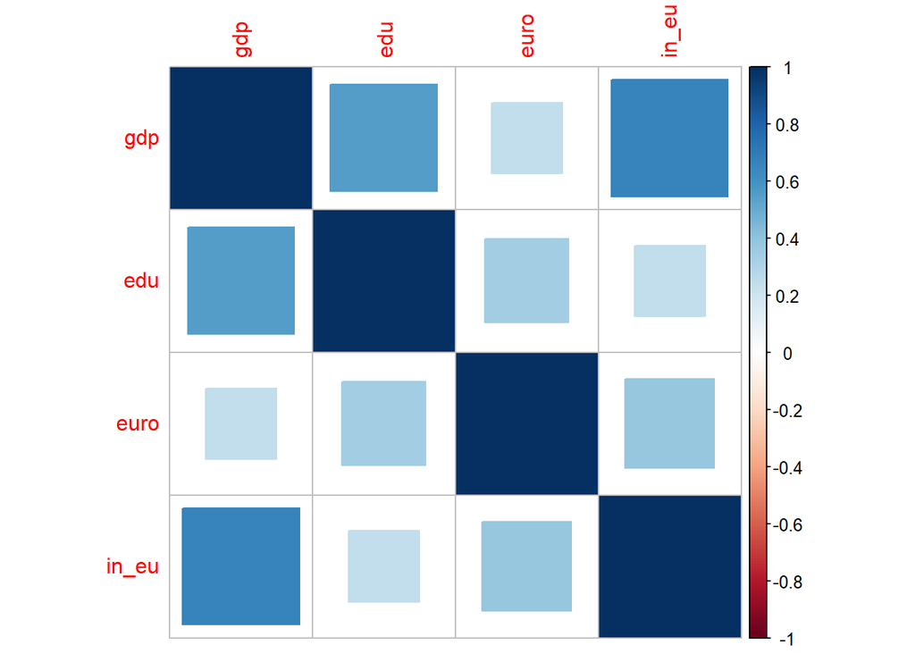

```r
corrplot(res$r, method = 'square')
```

Poďme teda odstrániť regresory ktoré sú zbytočné. Nato použijem faktor zväčšenia rozptylu **VIF**.

```r
data.frame(vif(lm(salary ~ gdp + euro + edu + in_eu, data = data)))
```

```
##       vif.lm.salary...gdp...euro...edu...in_eu..data...data..
## gdp                                                  2.678402
## euro                                                 1.337564
## edu                                                  1.713801
## in_eu                                                2.205188
```

Bežnou praxou je odstraňovať regresory, ktoré majú VIF vyššie ako 5, poprípade 10. Napriek tomu, že polovica testov napovedá problémy s kolinearitou, najvyšší odhad spomedzi korelačných koeficientov je však $0.67$. Hodnota VIF, však nepracuje s dvojicami, ale snaží sa nájsť “vinníka”. Pri vynechaní $k$-tého regresora spočíta koeficient determinácie $R_k$. Táto hodnota teda udáva podiel variability vysvetlený ostatnými regresormi. No, $1 - R_k$ potom bude časť, ktorú ostatné nevysvetľujú. Hodnota $\mathrm{VIF}_k = \frac{1}{1-R_k}$ teda udáva koľkokrát sa zväčší variabilita modelu ako dôsledok kolinearity $k$-tého regresora.

Jedno z vysvetlení prečo nemáme hodnoty nad 5, je to, že síce jednotlivé dvojice sú korelované, dôležité je, že nie príliš, resp. že nedokážeme nájsť regresor, ktorý by bol vyjadriteľný nejakým skalárnym súčinom vektora koeficientov a vektora zvyšných regresorov. Zjavne, každý z regresorov nesie podiel variability vysvetľovanej veličiny. Preto si dovolím použiť všetky regresory.

## Úloha 3

- Pomocí lineárního regresního modelu nebo jeho variant zkoumejte závislost mezd na všech regresorech.
- Prakticky interpretujte hodnoty odhadů regresních koeficientů.
- Zhodnoťte kvalitu modelu.
- Identifikujte odlehlá pozorování a prozkoumejte multikolinearitu.
- Otestujte předpoklady modelu - pokud nebudou splněny, navrhněte a vyzkoušejte metody, které nesplnění kompenzují nebo se bez předpokladů obejdou.
- Pomocí vhodných nástrojů se pokuste najít finální (pod-)model, který chování mezd dobře vysvětluje, ale neobsahuje nevýznamné komponenty. Prakticky interpretujte získané výsledky.

### Lineárny model bez interakcií

Vyskúšam jednoduchú lineárnu regresiu so všetkými vyššie vybranými regresormi bez interakcií. Formálne:

$$Y = \beta_0 + \beta_1 \cdot \text{GDP}
+ \beta_2 \cdot \text{euro} + \beta_3 \cdot \text{in_eu} + \beta_4 \cdot
\text{in_eu} + \epsilon, \mathrm{E} \epsilon = 0$$

```r
fit_all = lm(salary ~ gdp + euro + edu + in_eu, data = data)
summary(fit_all)
```

```
##
## Call:
## lm(formula = salary ~ gdp + euro + edu + in_eu, data = data)
##
## Residuals:
##      Min       1Q   Median       3Q      Max
## -1024.07  -315.20   -81.09   315.83  1027.73
##
## Coefficients:
##               Estimate Std. Error t value Pr(>|t|)
## (Intercept) -1.535e+02  4.369e+02  -0.351   0.7289
## gdp          4.733e-02  8.255e-03   5.733 1.09e-05 ***
## euro1       -2.248e+02  2.432e+02  -0.924   0.3658
## edu          2.670e+01  1.896e+01   1.408   0.1736
## in_eu        1.891e+01  7.765e+00   2.435   0.0239 *
## ---
## Signif. codes:  0 '***' 0.001 '**' 0.01 '*' 0.05 '.' 0.1 ' ' 1
##
## Residual standard error: 494.8 on 21 degrees of freedom
## Multiple R-squared:  0.8866, Adjusted R-squared:  0.865
## F-statistic: 41.05 on 4 and 21 DF,  p-value: 1.221e-09
```

Model je možné interpretovať takto:

- Základný odhad v krajinách platiacich vlastnou menou je $-153$€.
- Za každé euro v HDP na obyvateľa sa mzda zvýši o $4.7$ centov.
- Ak krajina platí eurom, zo mzdy strhávame $225$€.
- Za každé percento obyvateľov s vysokoškolským vzdelaním pridávame $27$€.
- Za každý rok členstva si obyvatelia prilepšia o $19$€.

Z vyššie uvedených regresorov sú štatisticky významné len HDP na obyvateľa a dĺžka členstva, na hladine významnosti $5 \%$.

Pre istotu upozorňujem na možnú dezinterpretáciu regresného koeficientu pre HDP na obyvateľa. Môže sa zdať, že táto hodnota je veľmi nízka, každopádne je dôležité mať na pamäti, že vysvetľovaná premenná je **mesačná** mzda a HDP na obyvateľa je za celý **rok**.

Model má pomerne vysoký adjustovaný koeficient determinácie, avšak je očividné z $p$-hodnôt testov nulovosti regresných koeficientov, že najdôležitejším regresorom je HDP na obyvateľa, ktoré poskytuje dobrý odhad možno aj samo osebe. Ostatné koeficienty používa model zdá sa len na korekciu odhadov neštandardne chovajúcich sa dátových bodov vzhľadom k HDP.

Minimálne a maximálne reziduum zhruba $\pm 1000$€ je pomerne veľké. Avšak polovica reziduí sa nachádza medzi $\pm 300$€ čo pri takejto veĺkej škále priemerných platov je prijateľná hodnota. Očakávam teda, že budem mať nejaké odľahlé hodnoty.

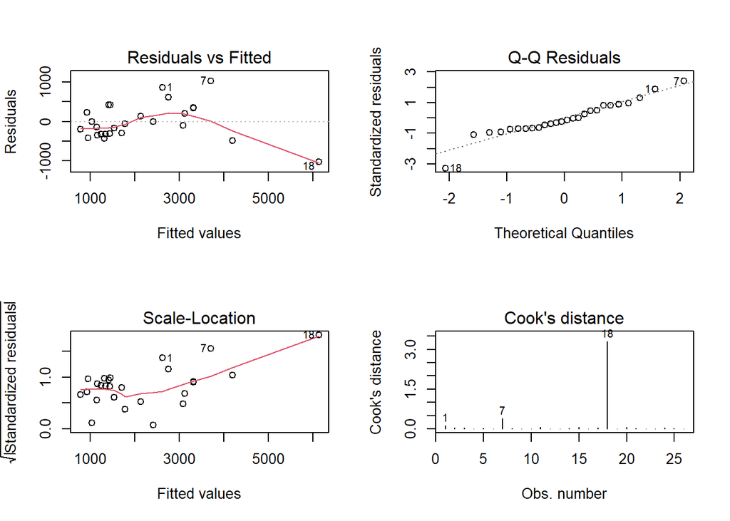

```r
par(mfrow=c(2, 2))
plot(fit_all, which = c(1, 2, 3, 4))
```

Zo všetkých vizualizácií reziduí jednoznačne vytŕča 18. krajina, ale aj s poradovým číslom 7.

```r
as.character(data[c(18, 7),]$geo)
```

```
## [1] "LU" "DK"
```

Vidíme, že sú nimi krajiny *Luxembursko* a *Dánsko*. Luxembursko nesmie nikoho prekvapiť, je to krajina príliš malá a preto sa odlišuje od celého rádu štatistík vrámci EÚ. Dánsko je krajina s najvyššími platmi ktorá nepoužíva euro.

Pozriem sa teraz na normalitu reziduí.

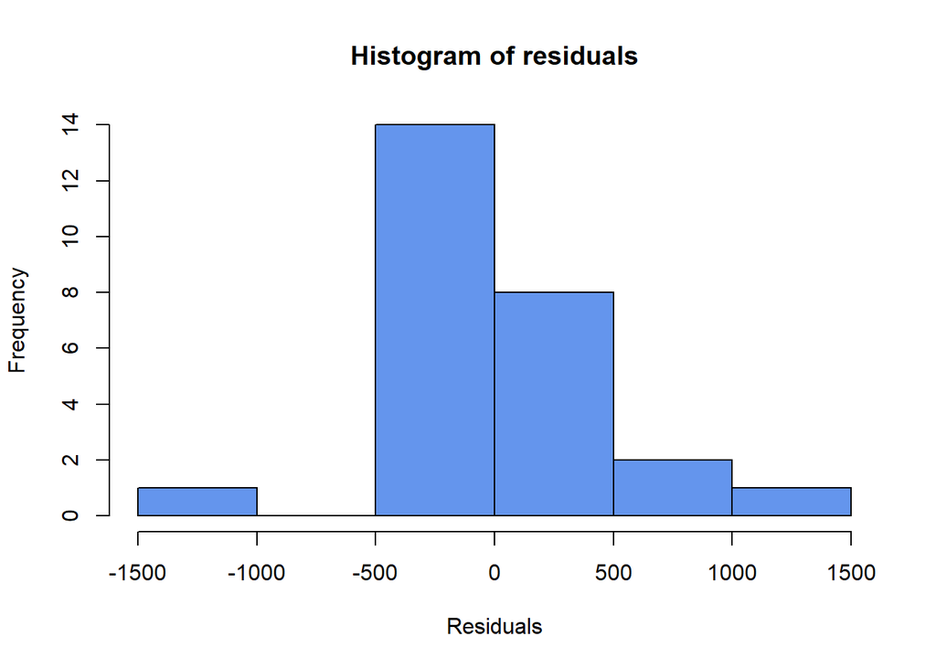

```r
hist(fit_all$residuals, col = 'cornflowerblue', xlab='Residuals', main='Histogram of residuals')
```

Tak ako sa zdalo vyššie, je vidno, že väčšina reziduí je pomerne blízka k nule, avšak máme aj odľahlé hodnoty. Poďme sa pozrieť, či to ešte splní podmienky normality.

$H_0 :$ Reziduá pochádzajú z normálneho rozdelenia.

$H_A :$ Neplatí $H_0$.

```r
shapiro.test(fit_all$residuals)
```

```
##
##  Shapiro-Wilk normality test
##
## data:  fit_all$residuals
## W = 0.96691, p-value = 0.5451
```

Na obvyklej hladine významnosti $5\%$ nezamietam hypotézu o normalite reziduí.

Teraz si vizualizujem ako sa predikcia modelu líši od reálnych hodnôt.

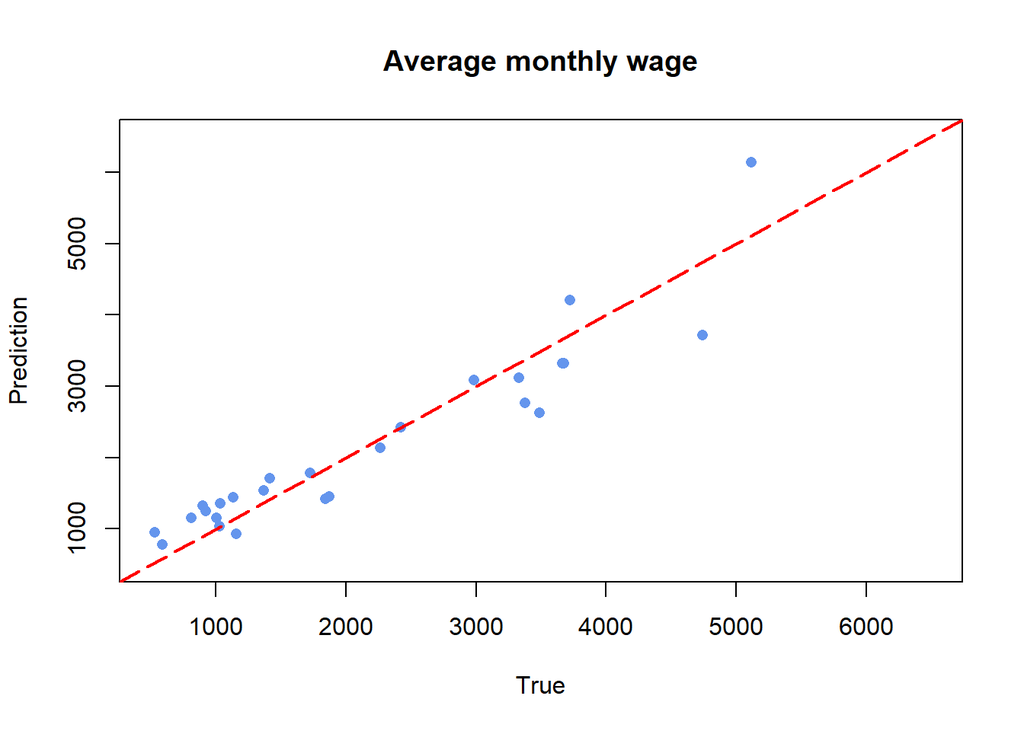

```r
pred = predict.lm(fit_all, data)
plot(data$salary, pred, xlim = c(500, 6500), ylim = c(500, 6500), pch = 16 , col = 'cornflowerblue',
     xlab = 'True', ylab = 'Prediction', main='Average monthly wage')
abline(a=0, b=1, lwd = 2, col='red', lty = 5)
```

Je vidno, že so zvyšujúcimi sa reálnymi hodnotami sa zvyšuje aj odchýlka predikcie. Poďme to otestovať *Breuschovým - Paganovým* testom.

$H_0 :$ Model je homoskedasticitný.

$H_A :$ Model je heteroskedasticitný.

```r
bptest(fit_all)
```

```
##
##  studentized Breusch-Pagan test
##
## data:  fit_all
## BP = 15.498, df = 4, p-value = 0.003772
```

Zamietam $H_0$ v prospech heteroskedasticity na hladine $5\%$.

### Lineárny model s interakciami

Model bez interakcií nespĺňal homoskedasticitu, preto vyskúšam model so všetkými interakciami.

```r
fit_all_int = lm(salary ~ gdp * edu * in_eu * euro, data = data)
summary(fit_all_int)
```

```
##
## Call:
## lm(formula = salary ~ gdp * edu * in_eu * euro, data = data)
##
## Residuals:
##     Min      1Q  Median      3Q     Max
## -185.31  -80.14    0.00    8.60  346.85
##
## Coefficients:
##                       Estimate Std. Error t value Pr(>|t|)
## (Intercept)         -2.077e+03  1.965e+04  -0.106    0.918
## gdp                  6.617e-01  2.088e+00   0.317    0.758
## edu                  4.418e+01  6.989e+02   0.063    0.951
## in_eu                1.230e+01  1.762e+03   0.007    0.995
## euro1                1.793e+03  1.971e+04   0.091    0.929
## gdp:edu             -2.187e-02  7.718e-02  -0.283    0.783
## gdp:in_eu           -4.387e-02  1.719e-01  -0.255    0.804
## edu:in_eu            5.554e+00  5.885e+01   0.094    0.927
## gdp:euro1           -5.481e-01  2.089e+00  -0.262    0.798
## edu:euro1           -5.269e+01  7.005e+02  -0.075    0.942
## in_eu:euro1         -7.899e+01  1.763e+03  -0.045    0.965
## gdp:edu:in_eu        1.418e-03  5.811e-03   0.244    0.812
## gdp:edu:euro1        2.143e-02  7.721e-02   0.278    0.787
## gdp:in_eu:euro1      4.559e-02  1.719e-01   0.265    0.796
## edu:in_eu:euro1     -2.286e+00  5.887e+01  -0.039    0.970
## gdp:edu:in_eu:euro1 -1.500e-03  5.811e-03  -0.258    0.802
##
## Residual standard error: 205.7 on 10 degrees of freedom
## Multiple R-squared:  0.9907, Adjusted R-squared:  0.9767
## F-statistic:  70.8 on 15 and 10 DF,  p-value: 4.093e-08
```

Dostávame čo sa reziduí týka veľmi presný model. O presnosti vypovedá aj vysoká hodnota adjustovaného koeficientu determinácie. Avšak nemáme ani jeden štatisticky významný regresný koeficient. To značí o vysokej miere kolinearity. To nie je prekvapením, keďže máme 16 rôznych koeficientov pre 26 dátových bodov. Model je veľmi ťažko interpretovateľný a pre dobro nás všetkých interpretáciu vynechávam.

V rýchlosti však zhrniem kvalitu modelu.

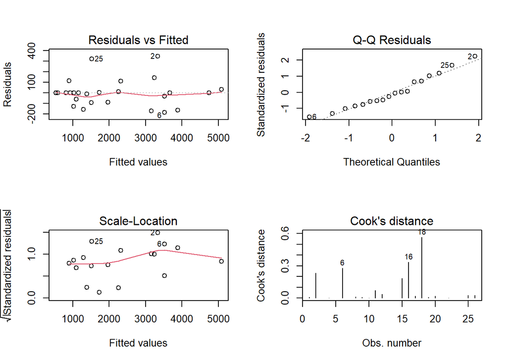

```r
par(mfrow=c(2, 2))
plot(fit_all_int, which = c(1, 2, 3, 4))
```

Reziduá sú relatívne nízke, pomerne homoskedastické.

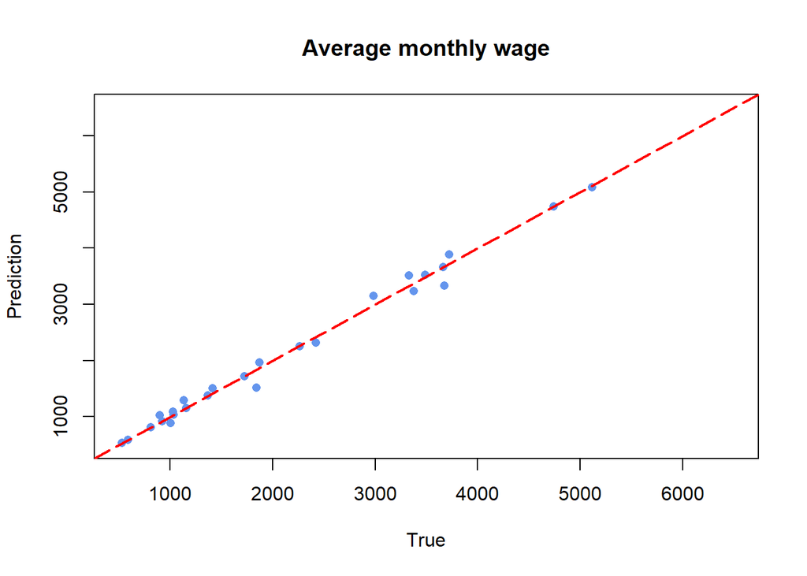

```r
pred = predict.lm(fit_all_int, data)
plot(data$salary, pred, xlim = c(500, 6500), ylim = c(500, 6500), pch = 16 , col = 'cornflowerblue',
     xlab = 'True', ylab = 'Prediction', main='Average monthly wage')
abline(a=0, b=1, lwd = 2, col='red', lty = 5)
```

Oproti vyššiemu modelu je tento veľmi presný.

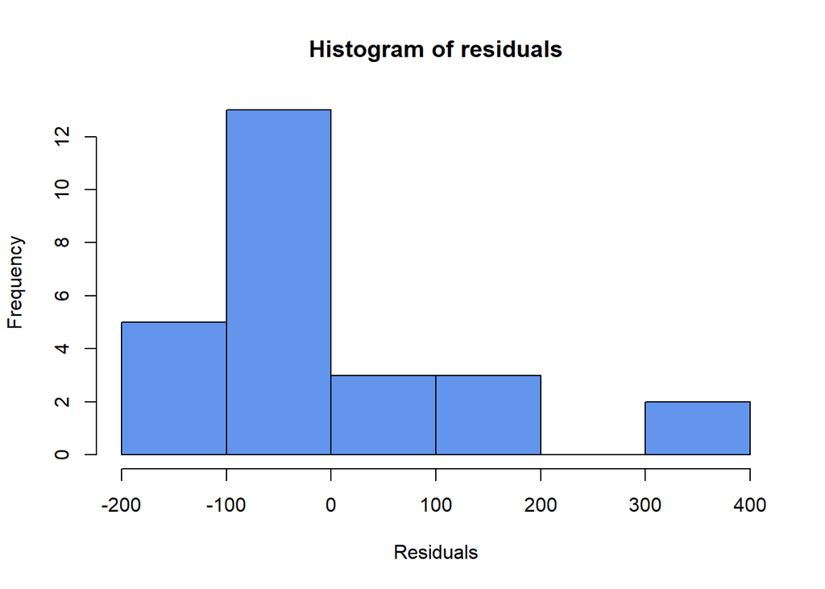

```r
hist(fit_all_int$residuals, col = 'cornflowerblue', xlab='Residuals', main='Histogram of residuals')
```

Pre prílišné prispôsobenie sa modelu dátam, dostávame reziduá, ktoré sú príliš sústredené okolo priemeru a hodnoty, ktoré by vyššie boli ešte v poriadku sa stávajú odľahlými. Otestujme to.

$H_0 :$ Reziduá pochádzajú z normálneho rozdelenia.

$H_A :$ Neplatí $H_0$.

```r
shapiro.test(fit_all_int$residuals)
```

```
##
##  Shapiro-Wilk normality test
##
## data:  fit_all_int$residuals
## W = 0.87167, p-value = 0.003858
```

Skutočne zamietam hypotézu o normalite reziduí na hladine významnosti $5\%$.

### Výber finálneho modelu

Vyššie dve modely nám pekne ukázali extrémy všeobecne všetkých modelov. Na jednej strane máme jednoduchý ale nepresný model a na strane druhej takmer exaktne presný avšak ťažko pochopiteľný.

Skvelým nástrojom `R`, ktorý nám pomôže nájsť kompromis je `step` využívajúci ešte perfektnejší nástroj štatistiky `AIC` - Akaikeho informačné kritérium. Tento ukazateľ sa spočíta z vierohodnostnej funkcie odhadu regresných koeficientov a ich počtom. Pričom cieľom je nájsť najmenšiu takúto hodnotu. Funkcia `step` nato potom používa priamočiary algoritmus a to taký, že začína s prázdnym modelom, predikujúcim konštantu, potom pri každej iterácii pridá regresor, alebo interakciu z už pridaných regresorov, ktorý znižuje hodnotu `AIC` najviac. Toto sa opakuje až do chvíle, keď už nie je možné pridať regresor, ktorý znižuje `AIC`.

```r
step(lm(data$salary~1),
     scope = list(lower=~1, upper=~data$gdp * data$edu * data$in_eu * data$euro))
```

```
## Start:  AIC=375.66
## data$salary ~ 1
##
##              Df Sum of Sq      RSS    AIC
## + data$gdp    1  38617679  6720723 328.03
## + data$in_eu  1  24069824 21268577 357.98
## + data$edu    1  14104084 31234318 367.97
## <none>                    45338402 375.66
## + data$euro   1   2638242 42700160 376.10
##
## Step:  AIC=328.03
## data$salary ~ data$gdp
##
##              Df Sum of Sq      RSS    AIC
## + data$in_eu  1   1040071  5680652 325.66
## <none>                     6720723 328.03
## + data$edu    1    127120  6593603 329.53
## + data$euro   1      9581  6711142 329.99
## - data$gdp    1  38617679 45338402 375.66
##
## Step:  AIC=325.66
## data$salary ~ data$gdp + data$in_eu
##
##                       Df Sum of Sq      RSS    AIC
## + data$gdp:data$in_eu  1   2799931  2880721 310.00
## <none>                              5680652 325.66
## + data$edu             1    330125  5350527 326.10
## + data$euro            1     53666  5626986 327.41
## - data$in_eu           1   1040071  6720723 328.03
## - data$gdp             1  15587926 21268577 357.98
##
## Step:  AIC=310
## data$salary ~ data$gdp + data$in_eu + data$gdp:data$in_eu
##
##                       Df Sum of Sq     RSS    AIC
## + data$euro            1    292684 2588037 309.22
## <none>                             2880721 310.00
## + data$edu             1     12441 2868280 311.89
## - data$gdp:data$in_eu  1   2799931 5680652 325.66
##
## Step:  AIC=309.22
## data$salary ~ data$gdp + data$in_eu + data$euro + data$gdp:data$in_eu
##
##                        Df Sum of Sq     RSS    AIC
## + data$in_eu:data$euro  1    424417 2163620 306.56
## <none>                              2588037 309.22
## + data$gdp:data$euro    1    189284 2398752 309.24
## - data$euro             1    292684 2880721 310.00
## + data$edu              1     86768 2501269 310.33
## - data$gdp:data$in_eu   1   3038949 5626986 327.41
##
## Step:  AIC=306.56
## data$salary ~ data$gdp + data$in_eu + data$euro + data$gdp:data$in_eu +
##     data$in_eu:data$euro
##
##                        Df Sum of Sq     RSS    AIC
## <none>                              2163620 306.56
## + data$edu              1     40463 2123157 308.07
## + data$gdp:data$euro    1     23883 2139737 308.27
## - data$in_eu:data$euro  1    424417 2588037 309.22
## - data$gdp:data$in_eu   1   1660644 3824264 319.37
```

```
##
## Call:
## lm(formula = data$salary ~ data$gdp + data$in_eu + data$euro +
##     data$gdp:data$in_eu + data$in_eu:data$euro)
##
## Coefficients:
##           (Intercept)               data$gdp             data$in_eu
##            -5.637e+02              9.008e-02              6.092e+01
##            data$euro1    data$gdp:data$in_eu  data$in_eu:data$euro1
##             1.725e+02             -9.192e-04             -2.460e+01
```

```r
fit_lowest_aic = lm(formula = salary ~ gdp + in_eu + euro + gdp:in_eu + in_eu:euro, data = data)
summary(fit_lowest_aic)
```

```
##
## Call:
## lm(formula = salary ~ gdp + in_eu + euro + gdp:in_eu + in_eu:euro,
##     data = data)
##
## Residuals:
##     Min      1Q  Median      3Q     Max
## -399.86 -203.44   10.18  199.48  645.90
##
## Coefficients:
##               Estimate Std. Error t value Pr(>|t|)
## (Intercept) -5.637e+02  2.165e+02  -2.604 0.016982 *
## gdp          9.008e-02  1.134e-02   7.940 1.31e-07 ***
## in_eu        6.092e+01  1.152e+01   5.289 3.55e-05 ***
## euro1        1.725e+02  2.648e+02   0.651 0.522231
## gdp:in_eu   -9.192e-04  2.346e-04  -3.918 0.000852 ***
## in_eu:euro1 -2.460e+01  1.242e+01  -1.981 0.061545 .
## ---
## Signif. codes:  0 '***' 0.001 '**' 0.01 '*' 0.05 '.' 0.1 ' ' 1
##
## Residual standard error: 328.9 on 20 degrees of freedom
## Multiple R-squared:  0.9523, Adjusted R-squared:  0.9403
## F-statistic: 79.82 on 5 and 20 DF,  p-value: 1.626e-12
```

Algoritmus nám teda z regresorov vylúčil vzdelanie. Výsledný model však obsahuje štatisticky nevýznamný regresor meny, preto ho odstránim a pozriem sa ako to ovplyvní model.

Formálne teda budem predpokladať, že:

$$Y= \beta_0 + \beta_1 \cdot \text{GDP} +
\beta_2 \cdot \text{in_eu} + \beta_3 \cdot (\text{GDP} \cdot
\text{in_eu}) + \beta_4 \cdot (\text{euro} \cdot \text{in_eu}) +
\epsilon, \mathrm{E} \epsilon = 0$$

```r
fit_fin = lm(formula = salary ~ gdp + in_eu + gdp:in_eu + in_eu:euro, data=data)
summary(fit_fin)
```

```
##
## Call:
## lm(formula = salary ~ gdp + in_eu + gdp:in_eu + in_eu:euro, data = data)
##
## Residuals:
##     Min      1Q  Median      3Q     Max
## -425.32 -225.36  -10.14  190.44  593.12
##
## Coefficients:
##               Estimate Std. Error t value Pr(>|t|)
## (Intercept) -5.148e+02  2.002e+02  -2.571 0.017815 *
## gdp          9.355e-02  9.879e-03   9.469 4.99e-09 ***
## in_eu        5.706e+01  9.742e+00   5.858 8.17e-06 ***
## gdp:in_eu   -9.874e-04  2.070e-04  -4.770 0.000103 ***
## in_eu:euro1 -1.803e+01  7.138e+00  -2.526 0.019653 *
## ---
## Signif. codes:  0 '***' 0.001 '**' 0.01 '*' 0.05 '.' 0.1 ' ' 1
##
## Residual standard error: 324.4 on 21 degrees of freedom
## Multiple R-squared:  0.9513, Adjusted R-squared:  0.942
## F-statistic: 102.5 on 4 and 21 DF,  p-value: 1.833e-13
```

Je vidno, že získaný model má všetky koeficienty regresorov štatisticky významne odlišné od nuly na štandardnej hladine významnosti.

#### Interpretácia

Tento model je možné interpretovať ako:

- Počiatočná hodnota pre štáty prijaté do EÚ v 2015 s nulovým HDP je $-515$€.
- Za každé euro v HDP na obyvateľa pre čerstvých členov pripisujeme $0.094$€.
- Za každý rok v EÚ pripočítavame $57$€.
- Za každý rok v EÚ sa vplyv HDP znižuje o $0.001$€, napr. pre $10$ ročného člena pripisujeme za každé euro HDP $0.094 - 10 \cdot 0.001 = 0.084$€. Pre starších členov zjavne rast miezd vzhľadom k HDP jemne spomaľuje.
- Ak sa v krajine platí eurom, tak za každý rok členstva pripočítavme $57 - 18 = 39$€. Pre krajiny platiace eurom sa rast miezd vzhľadom k dĺžke členstva spomaľuje.

#### Analýza reziduí

Poďme sa pozrieť na reziduá modelu.

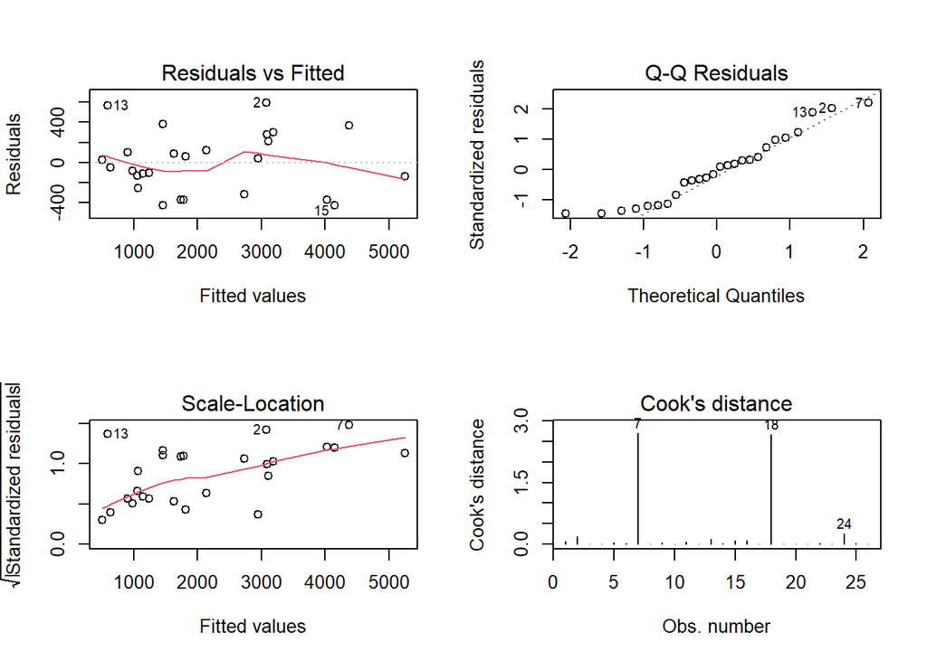

```r
par(mfrow=c(2, 2))
plot(fit_fin, which = c(1, 2, 3, 4))
```

Je možné vidieť, že *Luxembursko* a *Dánsko* sú opäť odľahlými bodmi.

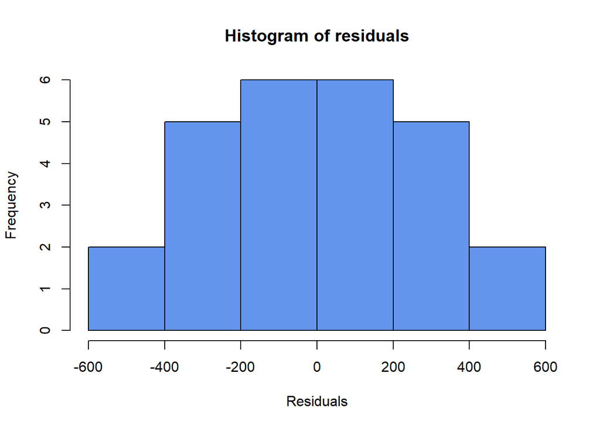

```r
hist(fit_fin$residuals, col = 'cornflowerblue', xlab='Residuals', main='Histogram of residuals')
```

Na grafe to vyzerá pomerne sľubne, je symetrický okolo nuly, ale pomerne málo bodov je blízko priemeru.

$H_0 :$ Reziduá pochádzajú z normálneho rozdelenia.

$H_A :$ Neplatí $H_0$.

```r
shapiro.test(fit_fin$residuals)
```

```
##
##  Shapiro-Wilk normality test
##
## data:  fit_fin$residuals
## W = 0.95501, p-value = 0.3029
```

Nezamietam normalitu redziduí na bežnej hladine významnosti.

*Breschovým - Paganovým* testom overím homoskedasticitu.

$H_0 :$ Model je homoskedasticitný.

$H_A :$ Model je heteroskedasticitný.

```r
bptest(fit_fin)
```

```
##
##  studentized Breusch-Pagan test
##
## data:  fit_fin
## BP = 1.7954, df = 4, p-value = 0.7733
```

Nezamietam homoskedasticitu na bežnej hladine významnosti.

#### Vizualizácia modelu

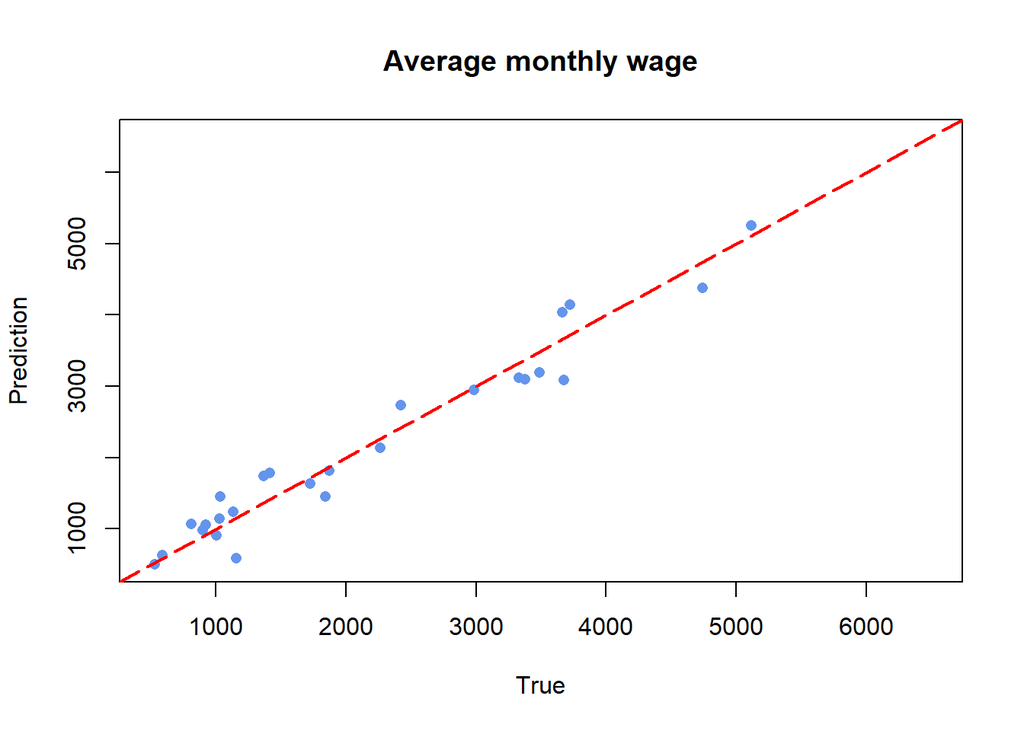

```r
pred = predict.lm(fit_fin, data)
plot(data$salary, pred, xlim = c(500, 6500), ylim = c(500, 6500), pch = 16 , col = 'cornflowerblue',
     xlab = 'True', ylab = 'Prediction', main='Average monthly wage')
abline(a=0, b=1, lwd = 2, col='red', lty = 5)
```

Model vyzerá byť o čosi nepresnejší ako komplikovaný s interakciami. Je ale vidno zlepšenie oproti jednoduchému modelu bez interakcií. Hlavne čo sa týka variability modelu v závislosti na hodnote vysvetľovanej premennej.

#### Test redukcie modelu

Následne sa pozriem, či je možné bez väčšej straty na presnosti redukovať pôvodný model so všetkými interakciami na najnižší s AIC skóre a na model po odobratí eura. Testy prevediem $\chi^2$ aj $\mathrm{F}$ testom.

```r
anova(fit_fin, fit_lowest_aic, fit_all_int, test='Chisq')
```

```
## Analysis of Variance Table
##
## Model 1: salary ~ gdp + in_eu + gdp:in_eu + in_eu:euro
## Model 2: salary ~ gdp + in_eu + euro + gdp:in_eu + in_eu:euro
## Model 3: salary ~ gdp * edu * in_eu * euro
##   Res.Df     RSS Df Sum of Sq  Pr(>Chi)
## 1     21 2209518
## 2     20 2163620  1     45898    0.2975
## 3     10  422951 10   1740669 1.059e-05 ***
## ---
## Signif. codes:  0 '***' 0.001 '**' 0.01 '*' 0.05 '.' 0.1 ' ' 1
```

```r
anova(fit_fin, fit_lowest_aic, fit_all_int, test='F')
```

```
## Analysis of Variance Table
##
## Model 1: salary ~ gdp + in_eu + gdp:in_eu + in_eu:euro
## Model 2: salary ~ gdp + in_eu + euro + gdp:in_eu + in_eu:euro
## Model 3: salary ~ gdp * edu * in_eu * euro
##   Res.Df     RSS Df Sum of Sq      F  Pr(>F)
## 1     21 2209518
## 2     20 2163620  1     45898 1.0852 0.32207
## 3     10  422951 10   1740669 4.1155 0.01778 *
## ---
## Signif. codes:  0 '***' 0.001 '**' 0.01 '*' 0.05 '.' 0.1 ' ' 1
```

Obe testy dospeli k záveru, že odobratím eura z modelu s najnižším AIC nespôsobí štatisticky významnú stratu presnosti. Takisto však vidíme, že obe model so všetkými interakciami nie je možné zredukovať bez straty na presnosti. Keďže trpel vysokou kolinearitou a ani nemal normálne rozdelené reziduá, vyberám ako finálny model ten posledný.

Nasleduje generovanie grafov, použitých výhradne v krátkej správe (bez komentára, nezaujímavé).

```r
data_to_plot = data
data_to_plot$geo = c("AUT", "BEL", "BGR", "CYP", "CZE", "DEU", "DNK", "EST", "GRC", "ESP",
 "FIN", "FRA", "HRV", "HUN", "IRL", "ITA", "LTU", "LUX", "LVA", "MLT",
 "POL", "PRT", "ROU", "SWE", "SVN", "SVK")


fig = plot_ly(
  data = data_to_plot,
  type = 'choropleth',
  locations = ~geo,
  locationmode = 'ISO-3',
  z = ~gdp,
  colorscale = list(
    c(0.0, "#f5fdaeff"),
    c(0.5, "#48afa0ff"),
    c(1.0, "#035376ff")
  )
)

fig = fig %>% layout(
  margin = list(l = -500, r = 0, b = 0, t = 0),
  geo = list(
    scope = 'world',
    projection = list(type = "winkel tripel"),
    lonaxis = list(range = c(-20, 40)),
    lataxis = list(range = c(33, 72)),
    showcountries = TRUE,
    countrycolor = "white"
  )
)

fig
```

[interactive chart not shown]

```r
fig = plot_ly(
  data = data_to_plot,
  type = 'choropleth',
  locations = ~geo,
  locationmode = 'ISO-3',
  z = ~salary,
  colorscale = list(
    c(0.0, "#f5fdaeff"),
    c(0.5, "#48afa0ff"),
    c(1.0, "#035376ff")
  )
)

fig = fig %>% layout(
  margin = list(l = -500, r = 0, b = 0, t = 0),
  geo = list(
    scope = 'world',
    projection = list(type = "winkel tripel"),
    lonaxis = list(range = c(-20, 40)),
    lataxis = list(range = c(33, 72)),
    showcountries = TRUE,
    countrycolor = "white"
  )
)

fig
```

[interactive chart not shown]

```r
fig = plot_ly(
  data = data_to_plot,
  type = 'choropleth',
  locations = ~geo,
  locationmode = 'ISO-3',
  z = ~edu,
  colorscale = list(
    c(0.0, "#f5fdaeff"),
    c(0.5, "#48afa0ff"),
    c(1.0, "#035376ff")
  )
)

fig = fig %>% layout(
  margin = list(l = -500, r = 0, b = 0, t = 0),
  geo = list(
    scope = 'world',
    projection = list(type = "winkel tripel"),
    lonaxis = list(range = c(-20, 40)),
    lataxis = list(range = c(33, 72)),
    showcountries = TRUE,
    countrycolor = "white"
  )
)

fig
```

[interactive chart not shown]

```r
fig = plot_ly(
  data = data_to_plot,
  type = 'choropleth',
  locations = ~geo,
  locationmode = 'ISO-3',
  z = ~in_eu,
  colorscale = list(
    c(0.0, "#f5fdaeff"),
    c(0.5, "#48afa0ff"),
    c(1.0, "#035376ff")
  )
)

fig = fig %>% layout(
  margin = list(l = -500, r = 0, b = 0, t = 0),
  geo = list(
    scope = 'world',
    projection = list(type = "winkel tripel"),
    lonaxis = list(range = c(-20, 40)),
    lataxis = list(range = c(33, 72)),
    showcountries = TRUE,
    countrycolor = "white"
  )
)

fig
```

[interactive chart not shown]

```r
fig = plot_ly(
  data = data_to_plot,
  type = 'choropleth',
  locations = ~geo,
  locationmode = 'ISO-3',
  z = ~euro,
  colorscale = list(
    c(0.0, "#f5fdaeff"),
    c(1.0, "#035376ff")
  ),
  showscale = FALSE
)

fig = fig %>% layout(
  margin = list(l = -500, r = 0, b = 0, t = 0),
  geo = list(
    scope = 'world',
    projection = list(type = "winkel tripel"),
    lonaxis = list(range = c(-20, 40)),
    lataxis = list(range = c(33, 72)),
    showcountries = TRUE,
    countrycolor = "white"
  )
)

fig
```

[interactive chart not shown]